# Lab 3

Addison Schmidt

10/3/2021

```r
dat <- readxl::read_xls("./GSS.xls")
```

```r
library(ggplot2)
library(dplyr)
dat = dat[dat$"Highest year of school completed" != "No answer", ]
dat
```

```
## # A tibble: 64,712 x 9
##    `Gss year for this ~ `Respondent id n~ `Number of hours usu~ `Marital status`
##                   <dbl>             <dbl> <chr>                 <chr>
##  1                 1972                 1 Not applicable        Never married
##  2                 1972                 2 Not applicable        Married
##  3                 1972                 3 Not applicable        Married
##  4                 1972                 4 Not applicable        Married
##  5                 1972                 5 Not applicable        Married
##  6                 1972                 6 Not applicable        Never married
##  7                 1972                 7 Not applicable        Divorced
##  8                 1972                 8 Not applicable        Never married
##  9                 1972                 9 Not applicable        Never married
## 10                 1972                10 Not applicable        Married
## # ... with 64,702 more rows, and 5 more variables:
## #   Highest year of school completed <chr>, Respondents sex <chr>,
## #   Political party affiliation <chr>, General happiness <chr>,
## #   Ballot used for interview <chr>
```

```r
dat$`Highest year of school completed` = strtoi(dat$`Highest year of school completed`)
schoolByMarital = dat %>%
  group_by(`Marital status`) %>%
  summarize(meanSchoolCompleted = mean(`Highest year of school completed`)) %>%
  arrange(`meanSchoolCompleted`)
schoolByMarital
```

```
## # A tibble: 7 x 2
##   `Marital status` meanSchoolCompleted
##   <chr>                          <dbl>
## 1 No answer                       15.5
## 2 Divorced                        NA
## 3 Married                         NA
## 4 Never married                   NA
## 5 Separated                       NA
## 6 Widowed                         NA
## 7 <NA>                            NA
```

```r
betterEducated = dat %>%
  filter((`Marital status` == "Widowed" & `Highest year of school completed` > 11.19825) |
          (`Marital status` == "Seperated" & `Highest year of school completed` > 11.85580) |
          (`Marital status` == "Married" & `Highest year of school completed` > 12.96828) |
          (`Marital status` == "Divorced" & `Highest year of school completed` > 13.10582) |
          (`Marital status` == "Never married" & `Highest year of school completed` > 13.38954) |
          (`Marital status` == "No answer" & `Highest year of school completed` > 15.47826))

structure(betterEducated)
```

```
## # A tibble: 29,256 x 9
##    `Gss year for this ~ `Respondent id n~ `Number of hours usu~ `Marital status`
##                   <dbl>             <dbl> <chr>                 <chr>
##  1                 1972                 1 Not applicable        Never married
##  2                 1972                 4 Not applicable        Married
##  3                 1972                 6 Not applicable        Never married
##  4                 1972                 8 Not applicable        Never married
##  5                 1972                11 Not applicable        Married
##  6                 1972                16 Not applicable        Married
##  7                 1972                17 Not applicable        Married
##  8                 1972                19 Not applicable        Married
##  9                 1972                20 Not applicable        Never married
## 10                 1972                23 Not applicable        Married
## # ... with 29,246 more rows, and 5 more variables:
## #   Highest year of school completed <int>, Respondents sex <chr>,
## #   Political party affiliation <chr>, General happiness <chr>,
## #   Ballot used for interview <chr>
```

3.From the plot, we see that married people have the highest ratio of happiness to unhappiness, and that seperated have the least. Interestingly, those who declined to answer tended to have the second least portion of happiness, indicating a correlation between unwillingness to answer the question about marital stat and happiness level.

```r
dat = dat %>%
  filter(`General happiness` %in% c('Very happy', 'Pretty happy', 'Not too happy'))  %>%
  mutate(happy = (`General happiness` %in% c('Very happy', 'Pretty happy')))
happy = dat %>%
  filter(`General happiness` %in% c('Very happy', 'Pretty happy')) %>%
  group_by(`Marital status`) %>%
  summarise(num = n());

unhappy = dat %>%
  filter(`General happiness` %in% c('Not too happy')) %>%
  group_by(`Marital status`) %>%
  summarise(num = n());

out = data.frame("Marital status" = happy$`Marital status`, "Happy portion" = happy$num / (happy$num + unhappy$num))
out
```

```
##   Marital.status Happy.portion
## 1       Divorced     0.8098176
## 2        Married     0.9235350
## 3  Never married     0.8387806
## 4      No answer     0.7777778
## 5      Separated     0.7162881
## 6        Widowed     0.8039283
```

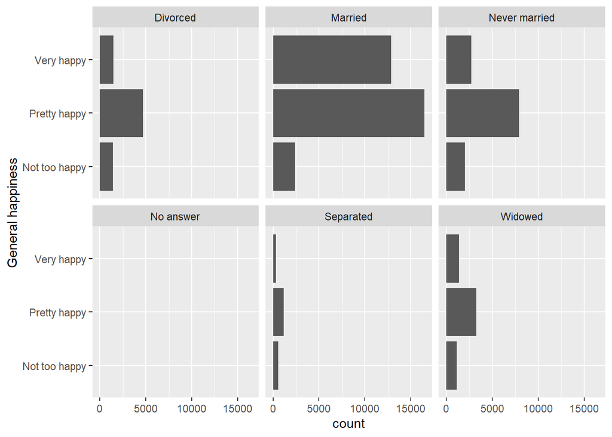

```r
ggplot(dat, aes(y=`General happiness`)) + geom_histogram(stat="count") + facet_wrap(~`Marital status`)
```

4. One interesting effect is that amongst those who are seperated, the happiness portion is much higher for republicans. To a lesser extent, the happiness portion is higher for republicans in other marital states as well.

```r
happyRepub = dat %>%
  filter(`General happiness` %in% c('Very happy', 'Pretty happy') & grepl("republican", `Political party affiliation`, fixed = TRUE)) %>%
  group_by(`Marital status`) %>%
  summarise(num = n());
unhappyRepub = dat %>%
  filter(`General happiness` %in% c('Not too happy') & grepl("republican", `Political party affiliation`, fixed = TRUE)) %>%
  group_by(`Marital status`) %>%
  summarise(num = n());
happyDem = dat %>%
  filter(`General happiness` %in% c('Very happy', 'Pretty happy') & grepl("democrat", `Political party affiliation`, fixed = TRUE)) %>%
  group_by(`Marital status`) %>%
  summarise(num = n());
unhappyDem = dat %>%
  filter(`General happiness` %in% c('Not too happy') & grepl("democrat", `Political party affiliation`, fixed = TRUE)) %>%
  group_by(`Marital status`) %>%
  summarise(num = n());

data.frame("Marital status" = happyRepub$`Marital status`, "Happy portion republican" = happyRepub$num / (happyRepub$num + unhappyRepub$num), "Happy portion democrat" = happyDem$num / (happyDem$num + unhappyDem$num))
```

```
##   Marital.status Happy.portion.republican Happy.portion.democrat
## 1       Divorced                0.8472393            0.794169301
## 2        Married                0.9505712            0.911557880
## 3  Never married                0.8897770            0.835918724
## 4      No answer                0.7500000            0.007936508
## 5      Separated                0.7400612            0.538395904
## 6        Widowed                0.8308586            0.784162063
```

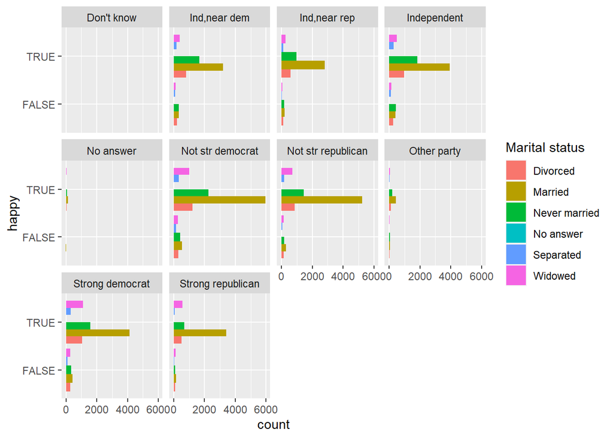

```r
ggplot(dat, aes(y=`happy`, fill=`Marital status`)) + geom_histogram(stat="count", position="dodge") + facet_wrap(~`Political party affiliation`)
```

5. We find that the female happiness ratio is very close to the male happiness ratio. This means the portions of happy males to unhappy males and happy females to unhappy females are equivalent to within our margin of error.

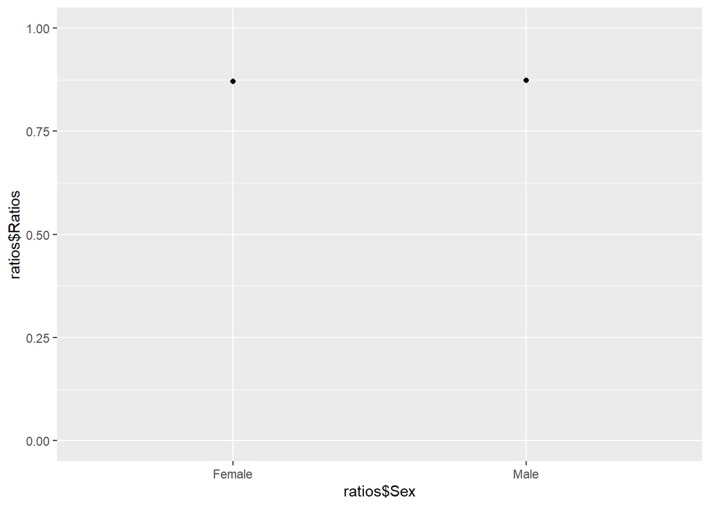

```r
happyFemale = dat %>%
  filter(`General happiness` %in% c('Very happy', 'Pretty happy') & `Respondents sex` == "Female") %>%
  summarise(num = n())
unhappyFemale = dat %>%
  filter(`General happiness` %in% c('Not too happy') & `Respondents sex` == "Female") %>%
  summarise(num = n())
happyMale = dat %>%
  filter(`General happiness` %in% c('Very happy', 'Pretty happy') & `Respondents sex` == "Male") %>%
  summarise(num = n())
unhappyMale = dat %>%
  filter(`General happiness` %in% c('Not too happy') & `Respondents sex` == "Male") %>%
  summarise(num = n())

ratios = data.frame("Sex" = c("Male", "Female"), "Ratios" = c(happyMale$num / (happyMale$num + unhappyMale$num), happyFemale$num / (happyFemale$num + unhappyFemale$num)))
ggplot(ratios, aes(x=ratios$Sex, y=ratios$Ratios)) + geom_point() + ylim(0, 1)
```